# Rstudio - Introdução aos modelos mistos

07 de Novembro de 2018

## O que é o R?

## Criadores do R

O programa R é resultado do esforço de **Robert Gentleman e Ross Ihaka**, professores de estatística da Universidade de Aucland, na Nova Zelândia, que desenvolveram o ambiente computacional e tornaram-no público a toda comunidade acadêmica.

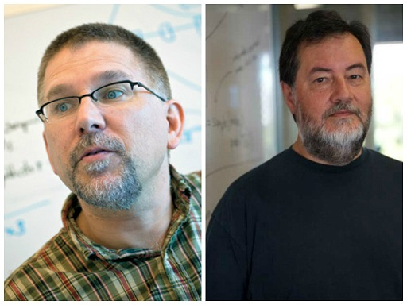

## Software R

R é uma linguagem de programação estatística de amplos objetivos. Podemos entender o **R** também como um conjunto de pacotes e ferramentas estatísticas que facilitam sua utilização, desde a criação de simples rotinas até análises de dados complexas, com visualizações bem acabadas.

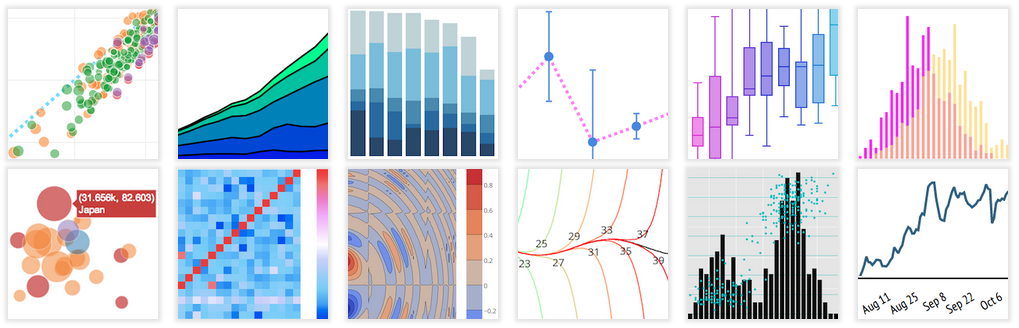

## Alguns motivos para aprender R

- É completamente gratuito;
- Curva de aprendizado bastante amigável, sendo fácil de se aprender;
- Quantidade de tutoriais;
- Amplamente utilizado pela comunidade acadêmica e pelo mercado;
- Quantidade de pacotes, para diversos tipos de necessidades;
- Ótima ferramenta para criar relatórios e gráficos.

## Rstudio

interface gráfica com diversas funcionalidades que melhoram ainda mais o uso e aprendizado do R. Na prática, o RStudio facilita muito o dia a dia de trabalho.

[figure not shown]

## Entorno do Rstudio

O Rstudio é dividido em quatro partes principais

[figure not shown]

## Aparência do Entorno Rstudio

[figure not shown]

## Definindo o Local dos Dados

O R sempre trabalha com o conceito de Working directory, ou seja, uma pasta de trabalho onde vai "ler" e "escrever" os dados. Para verificar qual o diretório que o R está "olhando", utilize o seguinte comando: *getwd()*

```r
getwd()
```

Para informar ao R em qual pasta ele deve ler os arquivos, utilizamos o comando set working directory, que muda o diretório padrão do R para leitura e escrita:

```r
setdw('D:/caminho/do/arquivo/arquivo.csv')
```

E que acontece se digita *R.Version()* ?

```r
R.Version()
```

## Ferramentas do R

## **ggplot2** : pacote de visualização de dados para R

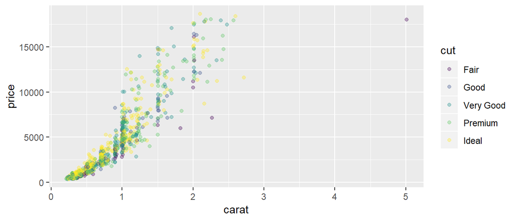

```r
library(ggplot2)
diamonds <- diamonds[sample(nrow(diamonds), 1000),]
ggplot(data = diamonds, aes(x = carat, y = price, colour = cut)) +
geom_point(alpha = 1/3)
```

## E mais…

```r
library(OutbreakTools)
library(rphylopic)
```

##### http://phylopic.org

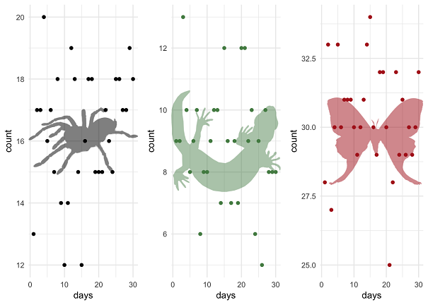

## Que são Modelos Mistos ?

## Modelo Estatistico

É uma expressão matematica que indica como uma variavel resposta (Y), se relaciona com uma ou mais variaveis explicativas (X)

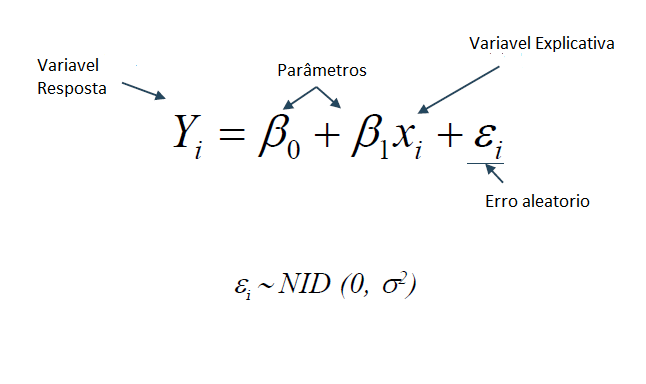

## Modelos Lineares e não Lineares

*Modelos Lineares nos parâmetros*

Os parametros encontram-se somando, nenhum deles aparece como exponente, multiplicado ou dividido por outro parametro. A Variavel resposta é uma combinação linear das variaveis explicativas.

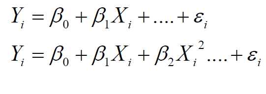

*Modelos não Lineares*

Os parametros aparecem na equação na forma não linear

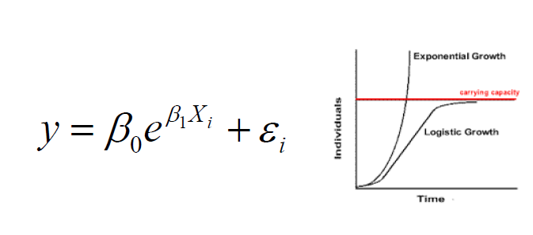

## Modelo Mistos

Modelos de efeitos mistos ou modelos multiníveis e são usados quando os dados têm uma forma hierárquica que pode ter coeficientes fixos e aleatórios, juntamente com vários termos de erro.

\(Y= X\beta + Z\alpha + \epsilon\)

Em que, \(Y\) : é o vetor de dados observados;

\(X\) : é a matriz de planejamento para os efeitos fixos;

\(\beta\) : é o vetor de parâmetros associados aos efeitos fixos;

\(\alpha\) : é o vetor de parâmetros associados aos efeitos aleatórios;

\(Z\) : é a matriz de planejamento para os efeitos aleatórios;

\(\epsilon\) : é o vetor de erros aleatórios.

tal que a estimativa da variável resposta (Y) é a soma da média da população (X \(\beta\)), obtida considerando os efeitos fixos, mais o valor predito da variável (Z\(\alpha\)), considerando os efeitos aleatórios.

- Efeitos fixos: Se todos os níveis de um determinado fator estiverem presentes no experimento (ou análise), ou seja, corresponderem aos níveis existentes na população, estes serão considerados fatores fixos;
- Efeitos aleatorios: se os níveis de um fator de uma população não estiverem presentes em sua totalidade, por razões diversas, estes serão denominados de fatores aleatórios.

## R packages

No R se-tem varios pacotes que nós permitem trabalhar com modelos mistos, sendo os mais conhecidos: o pacote *nlme()* e pacote *lme4()*.

model<- lme (y ~ fixed, random = ~1|random, data)

```r
install.packages("lme4")
install.packages("nlme")
#O pacote nlme() foi escrito por Jose Pinheiro e Douglas Bates
citation("nlme")
#O pacote lme() foi escrito por Douglas Bates
citation("lme4")
```

## Recursos

[figure not shown]

## E agora

[figure not shown]

## Depois

[figure not shown]

Colocaremos mãos na massa.

*Atividade*

https://github.com/lumimevi/